# Key takeaways from Agile PhD school

Veronika Mooses

28 11 2019

## Visualization

In my current article I investigate how cross-border short-term mobility varies among Estonians and Russian speaking minority. The novelty of the study lies in fact, that in activity-space segregation studies cross-border mobility has not been included, even though an increasing number of people commutes between different countries frequently. 75,118 people are included in my study.

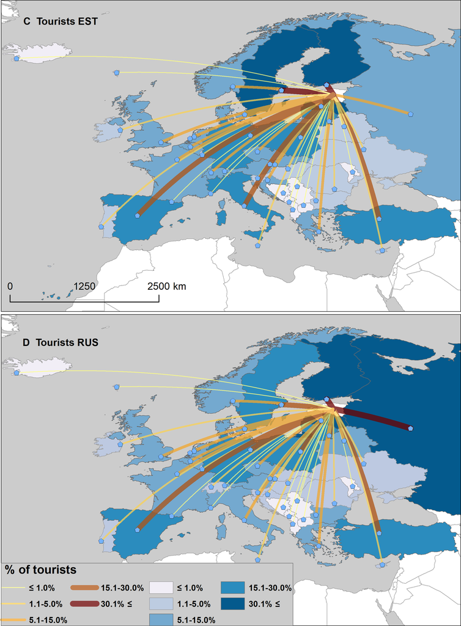

Figure 1 Tourists

**What to further consider/test based on Topi’s lecture:**  
1. Change the projection to LAEA-ETRS  
2. Test with different background colours

**Key takeaways**  
1. Visualizing dynamic processes  
2. Nice basemaps

## Reproducibility

**1. Passive mobile positioning roaming data**  
In terms of reproducibility, I cannot make the mobile positioning data open to everyone. However what I can provide is:  
* The reasoning why I cannot provide the data.  
* Description of the dataset that I use (metadata)  
* Synthetic data that is similar to my own data (hypothetical opportunity)  
* Workflow

*Technical details and workflow can be in GitHub and/or Zenodo repository. All the softwares, libraries and tools used will be listed in the meta-data of analysis and should be referenced to in methodology section of the article.*

**2. Open data - world administrative map, Estonian municipalities**  
* World Borders Map: Creative Commons Attribution-Share Alike License.  
* Estonian municipalities: instructions how to reference

**Key takeaways**  
* Basic understanding what is git, gitHub, basic commands  
* What is a README.md file  
* Pay attention to licenses!

## Science Communication

**Key takeaways**  
* Brown’s questions can be in handy for writing an abstract  
* To think how to develop the scientific “tension” (The Gap) that is the most engaging for the readers = “selling” your research idea to the reviewers.  
* Consider your audience and choose the language accordingly.